# 01.Descriptives

## Data

The datasets in here were worked up starting in the sub-folder `team_code` in the `team_code_R.Rmd` file and then in the project sub-folder `data_prep`.

1. `cri.csv` = model-level data, numerical values
2. `cri_team.csv` = team-level data
3. `cri_str.csv` = model-level data, string values

Note that Team 0 is actually the original study and hypothesis test on which these teams based their own work (Brady and Finnigan [2014](https://journals.sagepub.com/doi/full/10.1177/0003122413513022)). This is of potential interest for comparison, but removed in the final analyses.

## Model Specification Codebook

A descriptives table is far too large to add, therefore we simply append some summary statistics to the codebook and place this in the Supplementary Materials Appendix II. Model Specification Coding and Distribution.

## Descriptives

### Sample

Our sample is 72 teams including 161 researchers that submitted 1261 models. Of those teams, one never carried out the hypothesis test based on a failed measurement invariance test, another had all their 8 models fail to converge and one other had one model out of several fail to converge. The result was 71 teams with numeric results of their hypothesis tests derived from 1253 models produced by 161 researchers in total with an average of 2.244 researchers per team. There were 161 participants in 72 teams that produced 1261 models, average of 17.514 models per team.

### Summary Stats

We no longer use this approach but leave these tables here in case of interest. The codebook is now our main summary statistics location. Reproduced here.

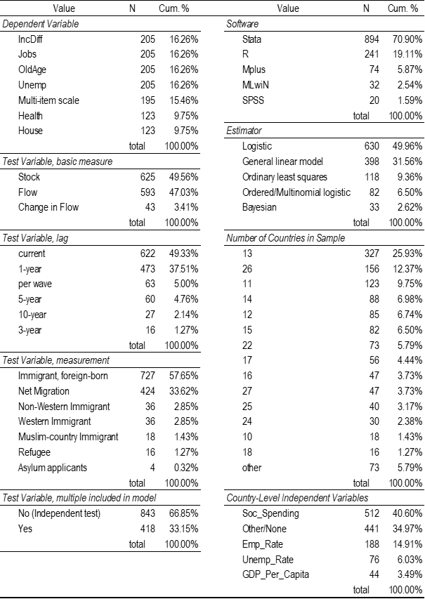

```r
knitr::include_graphics(here::here("results", "Tbl_codebook_desc.png"), dpi = 50)
```

### Table 1. Team-Results-Level Descriptive Statistics

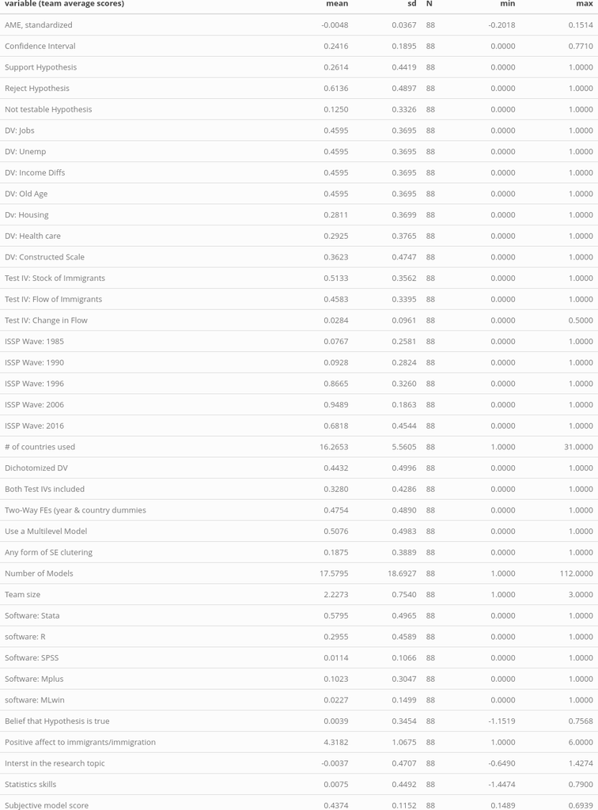

```r
knitr::include_graphics(here::here("results/Tbl_codebook.png"), dpi = 50)
```

### Table 2. Model-Level Descriptive Statistics

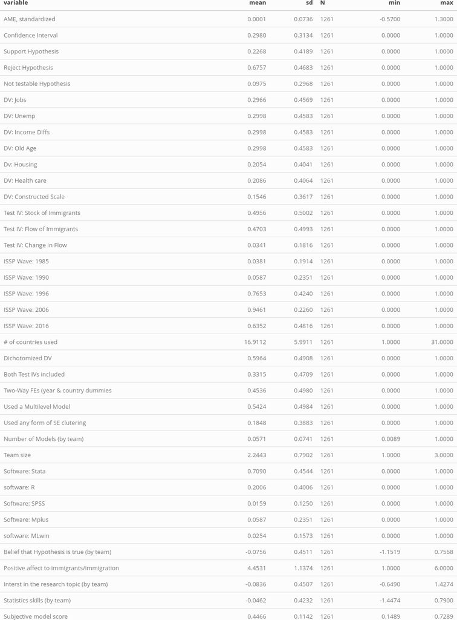

```r
knitr::include_graphics(here::here("results/Tbl_codebook2.png"), dpi = 50)
```

## Main Findings - Tables 1-3

This chunk preps some of the stats for Tables 1-3, these tables will be completed in `05_CRI_Main_Analyses.Rmd`.

```r
# remove original study and non-conclusive results
cri0 <- subset(cri, u_teamid != 0)
cri_team0 <- subset(cri_team, u_teamid != 0 & u_teamid != 1)

tm_avg <- round(mean(cri_team0$inv_weight, na.rm=T),2)
tm_sd <- round(sd(cri_team0$inv_weight, na.rm=T),2)
tm_min <- min(cri_team0$inv_weight, na.rm=T)
tm_max <- max(cri_team0$inv_weight, na.rm=T)
```

This chunk creates the matrix and exports it to csv for hand formatting and inserting into Supplementary Materials template.

```r
# create table frame
tbl1 <- matrix(nrow = 14, ncol = 3)
tbl1[1:14,1] <- c("","","Test Results","Positive","Insignificant","Negative","(test failed)",   "TOTAL","Sujective Conclusion: Hypothesis is?","Supported", "Not testable/inconclusive",    "Rejected", "TOTAL","")
tbl1[2,2] <- paste0("(out of ",length(unique(cri_team0$u_teamid))," teams)")
tbl1[2,3] <- paste0("(out of ",length(cri0$AME)," models)")
tbl1[1,2:3] <- c("Average Rate","Rate[a]")
tbl1[14,1] <- paste0("Of the ", length(unique(cri_team0$u_teamid)), " teams in the CRI,", sum(duplicated(cri_team0$u_teamid)), " of them treated stock and flow measures as independent tests of the hypothesis. Therefore, there are ", length(cri_team0$u_teamid), " team-level observed tests, each with an independent subjective conclusion. Of these ", length(cri_team0$u_teamid), " team-level results there was an average of ", tm_avg, " test models per team [sd =", tm_sd, ", min =", tm_min, ", max =", tm_max, "].")

# fill in descriptive results

# need to calculate rate carefully because teams 1 and 105 had failed tests

tbl1[4,2] <- mean(cri_team0$pos_test_pct_p05, na.rm = TRUE)
tbl1[4,3] <- mean(cri0$AME_sup_p05, na.rm = TRUE)
tbl1[5,2] <- mean(cri_team0$ns_test_pct_p05, na.rm = TRUE)
tbl1[5,3] <- mean(cri0$AME_ns_p05, na.rm = TRUE)
tbl1[6,2] <- mean(cri_team0$neg_test_pct_p05, na.rm = TRUE)
tbl1[6,3] <- mean(cri0$AME_neg_p05, na.rm = TRUE)
tbl1[7,2] <- 1- (sum(as.numeric(tbl1[4:6,2]), na.rm = TRUE))
tbl1[7,3] <- 1- (sum(as.numeric(tbl1[4:6,3]), na.rm = TRUE))

tbl1[8,2:3] <- 1

tbl1[10,2] <- (mean(cri_team0$Hsup, na.rm = TRUE)*87)/89
tbl1[11,2] <- ((mean(cri_team0$Hnotest, na.rm = TRUE)*87)+2)/89
tbl1[12,2] <- (mean(cri_team0$Hrej, na.rm = TRUE)*87)/89
tbl1[13,2] <- 1

write.csv(tbl1, file = here::here("results/tbl1.csv"))
```

### Correlation heatmap for Tbl1 obj and subj results

```r
cor_team <- dplyr::select(cri_team0, Hsup, Hno, Hrej, pos_test_pct_p05, ns_test_pct_p05, neg_test_pct_p05)
cormat <- round(cor(cor_team),2)

sq_cormat <- cormat[-c(4:6),-c(1:3)]
colnames(sq_cormat) <- c("Positive","Not Sig.","Negative")
rownames(sq_cormat) <- c("Supported","Inconclusive","Rejected")
sq_cormat_melted <- melt(sq_cormat)
```

```r
agg_png(filename = here::here("results/FigS10.png"), res = 144, height = 600, width = 700)
ggplot(data = sq_cormat_melted, aes(X1, X2, fill = value))+
 geom_tile(color = "white")+
 scale_fill_gradient2(low = "maroon", high = "green", mid = "grey",
   midpoint = 0, limit = c(-0.68,0.68), space = "Lab",
   name="Pearson\nCorrelation") +
  theme_minimal() +
  coord_fixed() +
  xlab("Subjective Team Conclusion\nabout Hypothesis Test") +
  ylab("AMEs, 95% CI\n(percentage by team)") +
  geom_text(aes(X1, X2, label = value), color = "black", size = 4) +
  theme(panel.grid.major = element_blank(),
        axis.title.x = element_text(vjust = -0.8),
      panel.border = element_blank(),
      panel.background = element_blank(),
      axis.ticks = element_blank())
dev.off()
```

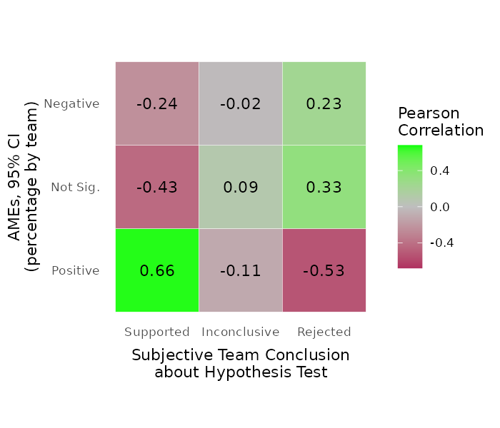

```r
knitr::include_graphics(here::here("results/FigS10.png"))
```

### Basic Descriptive Visualization of Outcomes

```r
cri0 <- subset(cri, u_teamid != 0) %>%
  # recode outliers to make better histogram
  mutate(AME_Zc = ifelse(AME_Z > 0.125, 0.15, ifelse(AME_Z < -0.125, -0.15, AME_Z)))

# add weighted mean & variance to plot
w_mean <- round(weighted.mean(cri$AME_Z, w = cri$inv_weight, na.rm = TRUE),4)
w_var <- round(wtd.var(cri$AME_Z, weights = cri$inv_weight, na.rm = TRUE),4)
```

```r
g1 <-  ggplot(data = cri0) +
  geom_histogram(aes(x = AME_Zc), breaks = c(-0.15,-0.125,-0.0625,-0.03125,-0.015625,-0.0078125,-0.00390625,0,0.00390625,0.0078125,0.015625,0.03125,0.0625,0.125,0.15)) +
  labs(x = "Model Results as Average Marginal Effects") +
  annotate("text", x = -0.15, y = 55, label = "AME < -0.15\ncombined", size = 2.5, hjust = 0) +
  geom_segment(aes(x = -0.14, y = 40, xend = -0.14, yend = 15), arrow = arrow(length = unit(0.3, "cm"))) +
  annotate("text", x = 0.15, y = 55, label = "AME > 0.15\ncombined", size = 2.5, hjust = 1) +
  annotate("text", x = 0.07, y = 140, label = paste0("μ", " = ", w_mean), size = 3, hjust = 0) +
  annotate("text", x = 0.07, y = 130, label = expression(paste(sigma^{2}, " = ")), size = 3, hjust = 0) +
  annotate("text", x = 0.1, y = 128, label = w_var, size = 3, hjust = 0) +
  geom_segment(aes(x = 0.14, y = 40, xend = 0.14, yend = 22), arrow = arrow(length = unit(0.3, "cm"))) +
  theme_classic()

g2 <- ggplot(data = cri_team0) +
  geom_bar(aes(x = Hresult)) +
  labs(x = "Team Conclusions about Hypothesis Test", y = "") +
  scale_x_discrete(labels=c("Not testable","Reject","Support")) +
  theme_classic()

agg_png(filename = here::here("results/FigS5.png"), res = 144, width = 1000)
ggpubr::ggarrange(g1,g2, labels = c("A","B"))
dev.off()
```

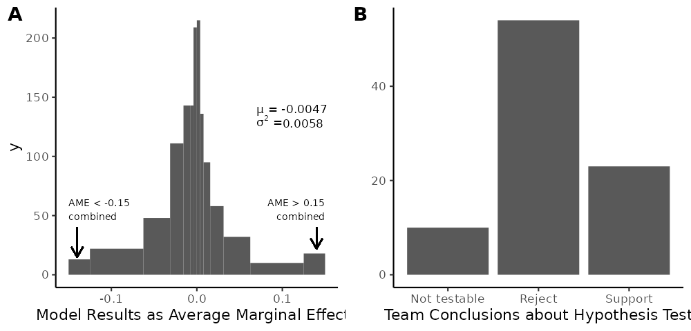

```r
knitr::include_graphics(here::here("results/FigS5.png"))
```

## Colophon

This file is part of https://github.com/nbreznau/CRI, the reproduction materials for [*Observing Many Researchers using the Same Data and Hypothesis Reveals a Hidden Universe of Uncertainty*](https://doi.org/10.31222/osf.io/cd5j9).